# Emily Chu Assignment 7&8

# Assignment

Data frame for this assignment: empdat_cor (download from Canvas)

##### Part I Correlation

**1. What is the appropriate measure(s) of association/correlation for current salary and education? Why?**  
Pearson’s r - we are testing the strength between two variables.

**2. Generate the appropriate measures(s) of association/correlation for current salary and education. Is the relationship significant? Why?**

```r
cor(empdat_cor$salary, empdat_cor$educ, method="pearson", use="complete.obs")
```

```
[1] 0.6605589
```

```r
cor.test(empdat_cor$salary, empdat_cor$educ) # give us the p - value, is it significant?
```

```
    Pearson's product-moment correlation

data:  empdat_cor$salary and empdat_cor$educ
t = 19.115, df = 472, p-value < 2.2e-16
alternative hypothesis: true correlation is not equal to 0
95 percent confidence interval:
 0.6065810 0.7084748
sample estimates:
      cor
0.6605589
```

```r
# What does R squared tell us?
CE <- cor(empdat_cor$salary, empdat_cor$educ, method="pearson", use="complete.obs")
CE^2
```

```
[1] 0.4363381
```

```r
library(dplyr)
corrmatrix <- cor(empdat_cor, use="complete.obs")
install.packages('corrplot')
```

```
Error in install.packages : Updating loaded packages
```

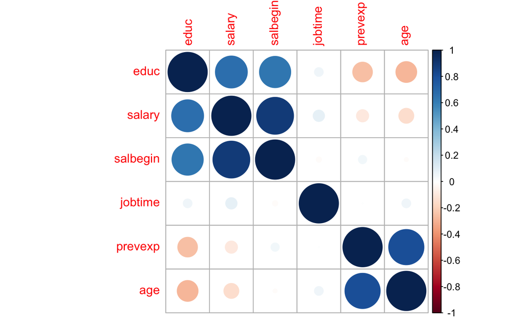

```r
library(corrplot)
corrplot(corrmatrix, method="circle") # corrmatrix is the name of the correlation matrix we created above
```

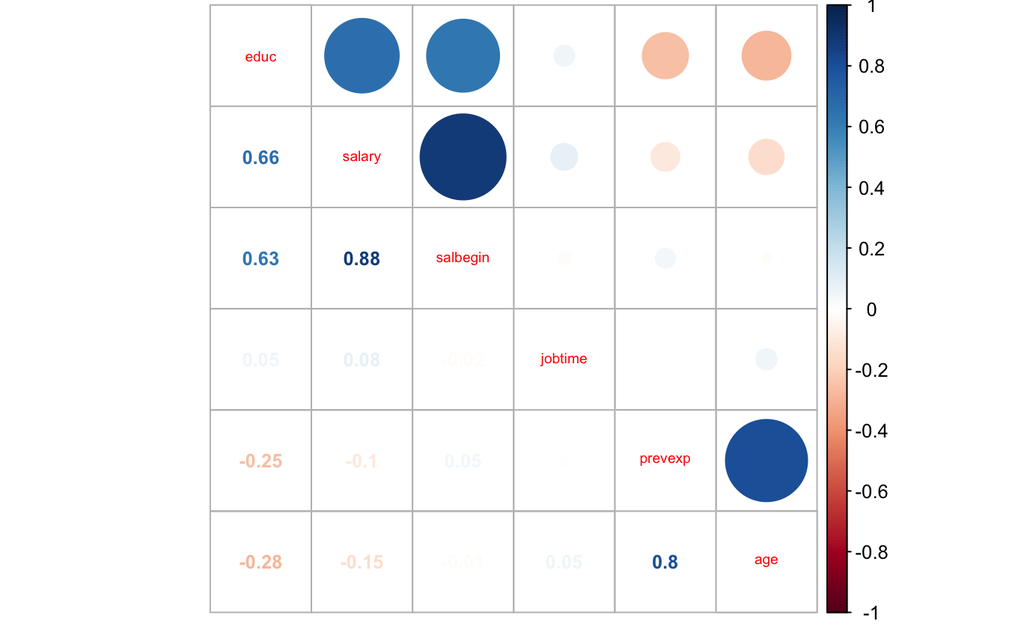

```r
corrplot.mixed(corrmatrix, number.cex = 0.8, tl.cex = 0.6)
```

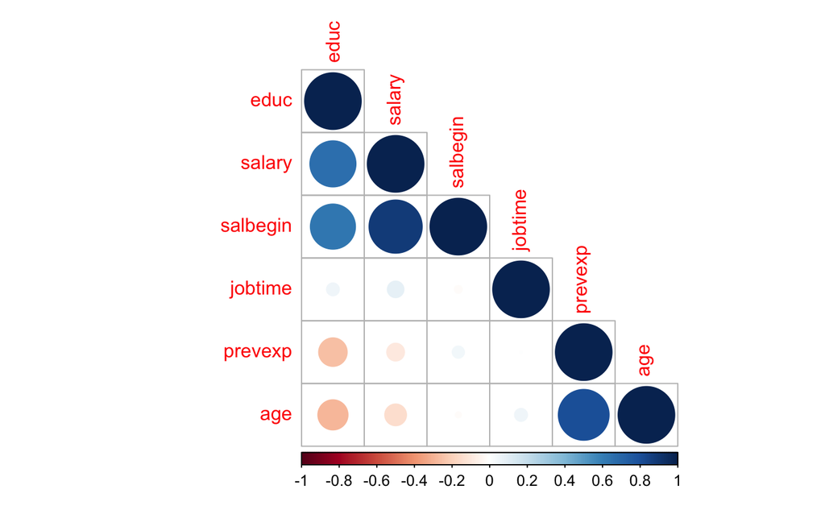

```r
#number.cex changes the size of the number fonts. tl.cex changes the size of the labels
corrplot(corrmatrix, type="lower")
```

##### Part II Simple Regression

*1. Generate and interpret a simple regression model for the relationship between current salary and age. Using the ‘sjPlot’ package to show the regression output.*  
*a. Show your regression model output.*

```r
summary(regression_1)
```

```
Call:
lm(formula = salary ~ age, data = empdat_cor)

Residuals:
   Min     1Q Median     3Q    Max
-18950 -10175  -5892   2685 103190

Coefficients:
            Estimate Std. Error t value             Pr(>|t|)
(Intercept) 41332.20    2296.37    18.0 < 0.0000000000000002 ***
age          -211.61      66.12    -3.2              0.00147 **
---
Signif. codes:  0 ‘***’ 0.001 ‘**’ 0.01 ‘*’ 0.05 ‘.’ 0.1 ‘ ’ 1

Residual standard error: 16930 on 471 degrees of freedom
  (1 observation deleted due to missingness)
Multiple R-squared:  0.02128,   Adjusted R-squared:  0.0192
F-statistic: 10.24 on 1 and 471 DF,  p-value: 0.001466
```

[output not shown]